# Multivariate Analysis of Variance (MANOVA)

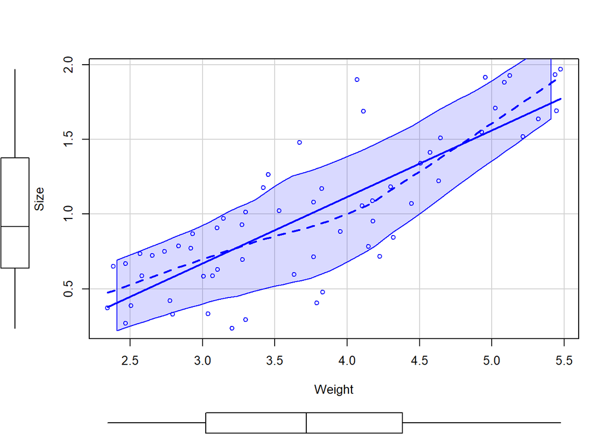

```r
# Option 2
library(car)
scatterplot(Size~Weight, data=filter(data, Type %in% "Apple"))
```

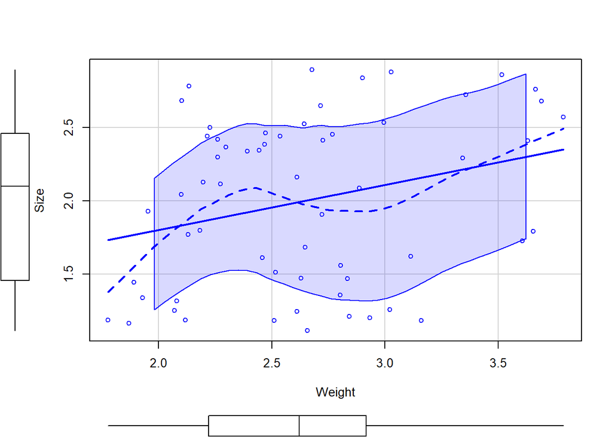

```r
scatterplot(Size~Weight, data=filter(data, Type %in% "Orange"))
```

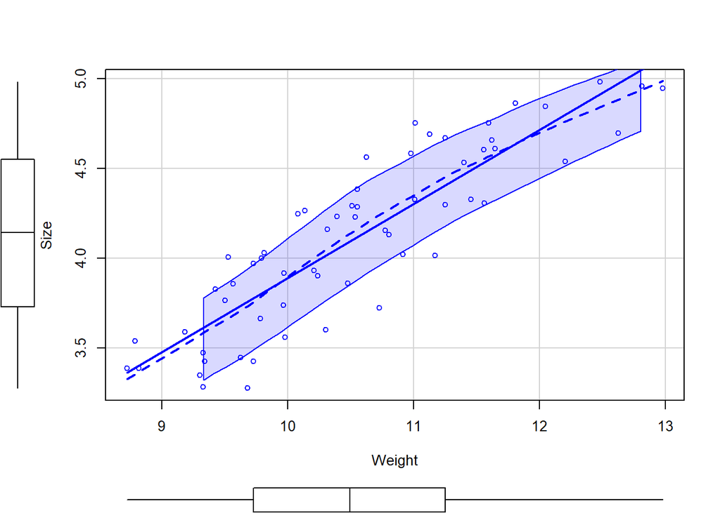

```r
scatterplot(Size~Weight, data=filter(data, Type %in% "Banana"))
```

### Homogeneity of covariances

Multivariate homogeneity of variance (homogeneity of covariances between groups). In case of violation of homogeneity of covariances, the MANOVA can be run only if the design is balanced (same sample size in every group). If homogeneity of covariances is not validated within an unbalanced design, Pillai’s test statistic must be used for the MANOVA (see subsection “MANOVA”).

```r
#p>0.001 on Box'M test (this test is highly sensitive)
box_m(data[, c("Size", "Weight")], data$Type)
```

### Homogeneity of variances

Homogeneity of variances between groups for each dependent variable.

In case of violation of homogeneity of variances, values of the dependent variable may be transformed, or a lower level of alpha for the p-value may be considered on the MANOVA results and post-hoc tests may be adjusted adequately (please refer to subsection “Univariate ANOVAs on each dependent variable”).

```r
#p>0.05 on Levene's test
data %>% gather(key = "Dep.var.", value = "score", Size, Weight) %>%
  group_by(Dep.var.) %>%
  levene_test(score ~ Type)
```

### MANOVA

Check wether there is a significant effect of Type on combined dependent variables.

```r
# You may choose Pillai, Wilks, Hotelling-Lawley or Roy test statistic
# Pillai is more robust to violation of parametricity, particularly in case of non-homogeneous covariances and unbalanced design.

mod <- lm(cbind(Size, Weight) ~ Type, data)
modManova <- Manova(mod, test.statistic = "Pillai")
modManova
```

### Post-hoc comparisons

#### Univariate ANOVAs on each dependent variable

NOTICE: According to which assumption of parametricity are met, the adequate ANOVA test must be chosen. Please refer to to the file named “ANOVA” for a detailed explanation.

In sum:

- a one-way ANOVA may be applied when homogeneity and normality are validated,
- a Welch one-way ANOVA may be applied in case of normality and non-homogeneity,
- a Kruskal-Wallis test may be applied in case of violation of normality and/or homogeneity.

```r
# ANOVA
mod1 <- data %>% gather(key = "Dep.var.", value = "score", Size, Weight) %>%
  group_by(Dep.var.) %>%  anova_test(score ~ Type)

# Or
# Welch
mod1 <- data %>% gather(key = "Dep.var.", value = "score", Size, Weight) %>%
  group_by(Dep.var.) %>%  welch_anova_test(score ~ Type)

# Or
# Kruskal-Wallis
mod1 <- data %>% gather(key = "Dep.var.", value = "score", Size, Weight) %>%
  group_by(Dep.var.) %>%  kruskal_test(score ~ Type)

# Adjust the p-values
mod1$HolmPval <- p.adjust(mod1$p, method = "holm") #Insert the method for p-adjustment that best suits your data

for (x in seq(from = 1, to = nrow(mod1), by = 1))
  if (mod1$HolmPval[x] < 0.001){
    mod1$p.adj.signif[x] <- "***"

    } else if  (mod1$HolmPval[x] < 0.01) {
      mod1$p.adj.signif[x] <- "**"
    } else if  (mod1$HolmPval[x] < 0.05) {
      mod1$p.adj.signif[x] <- "*"
    } else {
      mod1$p.adj.signif[x] <- "NS" }

mod1
```

#### 2-by-2 comparisons: adjust the p-value to the number of comparisons correcting for multiple comparisons

##### Case of previous univeriate one-way ANOVA

###### Compare to one control group (e.g., Banana)

```r
# Dunnett
# Define Banana as the reference
data$Type <- as.factor(data$Type);data$Type <- relevel(data$Type, ref="Banana")

# Check (must be the first)
levels(data$Type)

# Do Anova again with Banana as the reference (should not change the results)
data2 <- data %>% gather(key = "Dep.var.", value = "score", Size, Weight)
lmSize <- lm(score~Type, data=filter(data2, Dep.var. %in% "Size"))
lmWeight <- lm(score~Type, data=filter(data2, Dep.var. %in% "Weight"))
Anova(lmSize); Anova(lmWeight)
mod1

# 2-by-2 comparisons to reference
library(multcomp)
mc_dunnettSize <- glht(lmSize, linfct=mcp(Type="Dunnett"))
summary(mc_dunnettSize)

mc_dunnettWeight <- glht(lmWeight, linfct=mcp(Type="Dunnett"))
summary(mc_dunnettWeight)
```

###### All 2-by-2 comparisons

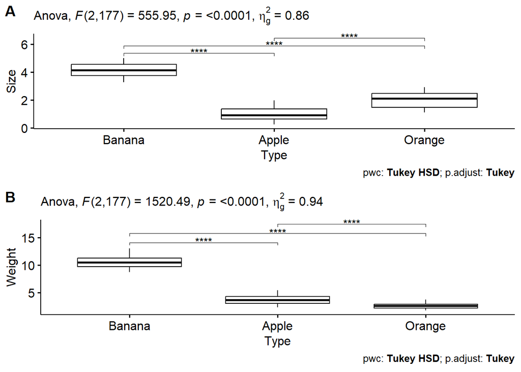

```r
# Tukey
mc_tukeySize <- glht(lmSize, linfct=mcp(Type="Tukey"))
summary(mc_tukeySize)

mc_tukeyWeight <- glht(lmWeight, linfct=mcp(Type="Tukey"))
summary(mc_tukeyWeight)

# Visualization: box plots with p-values

dataSize <- filter(data2, Dep.var. %in% "Size") %>% dplyr::select(-Dep.var.)
pwc <- dataSize %>% tukey_hsd(score~Type)

library(ggpubr)
pwc <- pwc %>% add_xy_position(x = "Type")

p <- ggboxplot(dataSize, x = "Type", y = "score") +
  stat_pvalue_manual(pwc, hide.ns = TRUE) +
  labs(subtitle = get_test_label(dataSize %>% anova_test(score~Type), detailed = TRUE),
    caption = get_pwc_label(pwc)) + ylab("Size")

dataWeight <- filter(data2, Dep.var. %in% "Weight") %>% dplyr::select(-Dep.var.)
pwc <- dataWeight %>% tukey_hsd(score~Type)

pwc <- pwc %>% add_xy_position(x = "Type")
p2 <- ggboxplot(dataWeight, x = "Type", y = "score") +
  stat_pvalue_manual(pwc, hide.ns = TRUE) +
  labs(subtitle = get_test_label(dataWeight %>% anova_test(score~Type), detailed = TRUE),
    caption = get_pwc_label(pwc)) + ylab("Weight")

ggarrange(p, p2,labels = c("A", "B"),ncol = 1, nrow = 2)
```

##### Case of previous univariate Welch one-way ANOVA

Notice: in case of comparison to a reference, pairwise t-tests may be applied, with no assumption of equal variances and correction for multiple comparisons (e.g., Bonferroni).

##### Compare to one control group (e.g., Banana)

```r
pwc3 <- dataSize %>%
  pairwise_t_test(score ~ Type, pool.sd = FALSE,
    p.adjust.method = "none")
pwc3


pwc4 <- dataWeight %>%
  pairwise_t_test(score ~ Type, pool.sd = FALSE,
    p.adjust.method = "none")
pwc4

#Define the reference
reference <- "Banana"; i <- 0; pwc5 <- data.frame(.y. = character(),
                                                  group1 = character(),
                                                  group2 = character(),
                                                  n1 = numeric(),
                                                  n2 = numeric(),
                                                  statistic = numeric(),
                                                  df = numeric(),
                                                  p = numeric(),
                                                  p.adj = numeric(),
                                                  p.adj.signif = character())

pwc6 <- pwc5

#Select the p-values of interest (comparisons with reference)

for (x in seq(from = 1, to = nrow(pwc3), by = 1)) {
  T1 <- pwc3$group1[x];  T2 <- pwc3$group2[x]

  if (T1[1] == reference | T2[1] == reference) {
    print(c("################## comparison = ", x, "contains ", reference));
    i <- i+1;
    pwc5[i,] <- pwc3[x,];
  }
}

# Adjust the p-values
pwc5$HolmPval <- p.adjust(pwc5$p, method = "holm") #Insert the method for p-adjustment that best suits your data

for (x in seq(from = 1, to = nrow(pwc5), by = 1))
  if (pwc5$HolmPval[x] < 0.001){
    pwc5$p.adj.signif[x] <- "***"

    } else if  (pwc5$HolmPval[x] < 0.01) {
      pwc5$p.adj.signif[x] <- "**"
    } else if  (pwc5$HolmPval[x] < 0.05) {
      pwc5$p.adj.signif[x] <- "*"
    } else {
      pwc5$p.adj.signif[x] <- "NS" }

pwc5

#Select the p-values of interest (comparisons with reference)
i <- 0;
for (x in seq(from = 1, to = nrow(pwc4), by = 1)) {
  T1 <- pwc4$group1[x];  T2 <- pwc4$group2[x]

  if (T1[1] == reference | T2[1] == reference) {
    print(c("################## comparison = ", x, "contains ", reference));
    i <- i+1;
    pwc6[i,] <- pwc4[x,];
  }
}

# Adjust the p-values
pwc6$HolmPval <- p.adjust(pwc6$p, method = "holm") #Insert the method for p-adjustment that best suits your data

for (x in seq(from = 1, to = nrow(pwc6), by = 1))
  if (pwc6$HolmPval[x] < 0.001){
    pwc6$p.adj.signif[x] <- "***"

    } else if  (pwc6$HolmPval[x] < 0.01) {
      pwc6$p.adj.signif[x] <- "**"
    } else if  (pwc6$HolmPval[x] < 0.05) {
      pwc6$p.adj.signif[x] <- "*"
    } else {
      pwc6$p.adj.signif[x] <- "NS" }

pwc6
```

###### All 2-by-2 comparisons

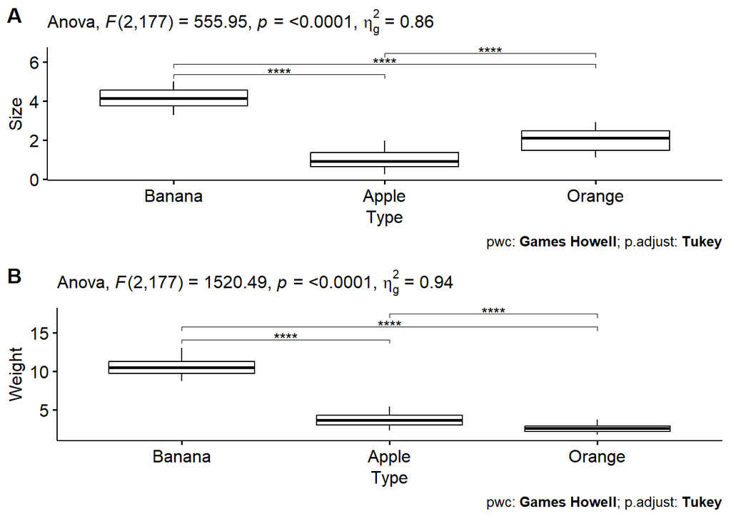

```r
pwc2Size <- dataSize %>% games_howell_test(score ~ Type)
pwc2Size

pwc2Weight <- dataWeight %>% games_howell_test(score ~ Type)
pwc2Weight

# Visualization: box plots with p-values

pwc2Size <- pwc2Size %>% add_xy_position(x = "Type")
p <- ggboxplot(dataSize, x = "Type", y = "score") +
  stat_pvalue_manual(pwc2Size, hide.ns = TRUE) +
  labs(subtitle = get_test_label(dataSize %>% anova_test(score~Type), detailed = TRUE),
    caption = get_pwc_label(pwc2Size)) + ylab("Size")

pwc2Weight <- pwc2Weight %>% add_xy_position(x = "Type")
p2 <- ggboxplot(dataWeight, x = "Type", y = "score") +
  stat_pvalue_manual(pwc2Weight, hide.ns = TRUE) +
  labs(subtitle = get_test_label(dataWeight %>% anova_test(score~Type), detailed = TRUE),
    caption = get_pwc_label(pwc2Weight)) + ylab("Weight")

ggarrange(p, p2,labels = c("A", "B"),ncol = 1, nrow = 2)
```

##### Case of previous Kruskal-Wallis test

##### Compare to one control group (e.g., Banana)

```r
# Dunnett's procedure
# All 2-by-2 comparisons without adjusting the p-value

pp_allSize <- pairwise.wilcox.test(dataSize$score, data$Type,p.adjust.method ="none" )
pp_allSize

pp_allWeight <- pairwise.wilcox.test(dataWeight$score, data$Type,p.adjust.method ="none" )
pp_allWeight

# Select the p-values of interest (comparisons with reference)

pvalSize <- data.frame(pp_allSize[["p.value"]])
pvalWeight <- data.frame(pp_allWeight[["p.value"]])


for (x in seq(from = 1, to = ncol(pvalSize)-1, by = 1)) {
  cols <- c(colnames(pvalSize)[x], colnames(pvalSize)[x+1])
  rows <- c(rownames(pvalSize)[x], rownames(pvalSize)[x+1])
}


reference <- "Banana"; i <- 0; pdunnSize <- data.frame(group1 = character(),
                                                   group2 = character(),
                                                   p = numeric(),
                                                   p.adj = numeric(),
                                                   p.adj.signif = character())


pdunnSize[1,1:ncol(pvalSize)] <- cols; pdunnSize[2,1:ncol(pvalSize)] <- c(cols[1], rows[2])
#pdunnSize[3,1:ncol(pvalSize)] <- rows

pdunnSize[1,3] <- pvalSize[1,1]; pdunnSize[2,3] <- pvalSize[2,1]; #pdunnSize[3,3] <- pvalSize[2,2]

#Adjust the p-values

pdunnSize$p.adj <- p.adjust(pdunnSize$p, method = "holm") #Insert the method for p-adjustment that best suits your data

for (x in seq(from = 1, to = nrow(pdunnSize), by = 1))
  if (pdunnSize$p.adj[x] < 0.001){
    pdunnSize$p.adj.signif[x] <- "***"
  } else if  (pdunnSize$p.adj[x] < 0.01) {
    pdunnSize$p.adj.signif[x] <- "**"
  } else if  (pdunnSize$p.adj[x] < 0.05) {
    pdunnSize$p.adj.signif[x] <- "*"
  } else {
    pdunnSize$p.adj.signif[x] <- "NS" }

pdunnSize

for (x in seq(from = 1, to = ncol(pvalWeight)-1, by = 1)) {
  cols <- c(colnames(pvalWeight)[x], colnames(pvalWeight)[x+1])
  rows <- c(rownames(pvalWeight)[x], rownames(pvalWeight)[x+1])
}


reference <- "Banana"; i <- 0; pdunnWeight <- data.frame(group1 = character(),
                                                   group2 = character(),
                                                   p = numeric(),
                                                   p.adj = numeric(),
                                                   p.adj.signif = character())


pdunnWeight[1,1:ncol(pvalWeight)] <- cols; pdunnWeight[2,1:ncol(pvalWeight)] <- c(cols[1], rows[2])
#pdunnWeight[3,1:ncol(pvalWeight)] <- rows

pdunnWeight[1,3] <- pvalWeight[1,1]; pdunnWeight[2,3] <- pvalWeight[2,1]; #pdunnWeight[3,3] <- pvalWeight[2,2]

#Adjust the p-values

pdunnWeight$p.adj <- p.adjust(pdunnWeight$p, method = "holm") #Insert the method for p-adjustment that best suits your data

for (x in seq(from = 1, to = nrow(pdunnWeight), by = 1))
  if (pdunnWeight$p.adj[x] < 0.001){
    pdunnWeight$p.adj.signif[x] <- "***"
  } else if  (pdunnWeight$p.adj[x] < 0.01) {
    pdunnWeight$p.adj.signif[x] <- "**"
  } else if  (pdunnWeight$p.adj[x] < 0.05) {
    pdunnWeight$p.adj.signif[x] <- "*"
  } else {
    pdunnWeight$p.adj.signif[x] <- "NS" }

pdunnWeight
```

##### 2-by-2 comparisons with correction for multiple testing

```r
ppSize <- pairwise.wilcox.test(dataSize$score, dataSize$Type,p.adjust.method ="holm" )
ppSize

ppWeight <- pairwise.wilcox.test(dataWeight$score, dataWeight$Type,p.adjust.method ="holm" )
ppWeight
```

##### Summary plot (example with case of previous one-way ANOVA at post-hoc)

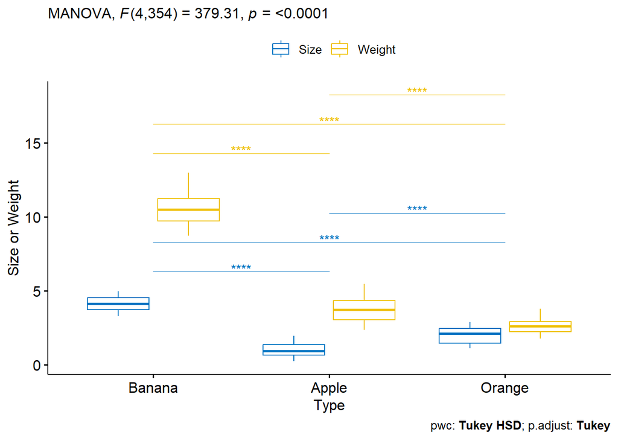

```r
pwc <- data %>%
  gather(key = "Dep.var.", value = "score", Size, Weight) %>%
  group_by(Dep.var.) %>%
  tukey_hsd(score ~ Type)
pwc


pwc <- pwc %>% add_xy_position(x = "Type")
test.label <- create_test_label(description = "MANOVA", statistic.text = quote(italic("F")),
  statistic = 379.31, p= "<0.0001", parameter = "4,354",
  type = "expression", detailed = TRUE)
ggboxplot(data, x = "Type", y = c("Size", "Weight"),
  merge = TRUE, palette = "jco") +
  stat_pvalue_manual(pwc, hide.ns = TRUE, tip.length = 0,
    step.increase = 0.0001, step.group.by = "Dep.var.",
    color = "Dep.var.") +
  labs(subtitle = test.label,
    caption = get_pwc_label(pwc, type = "expression")) + ylab("Size or Weight")
```

## *MANOVA as a multivariate linear regression*

```r
rm(list = ls())
library(readxl)
data <- read_excel("One-way-MANOVA - Regression.xlsx")
```

### Visualization

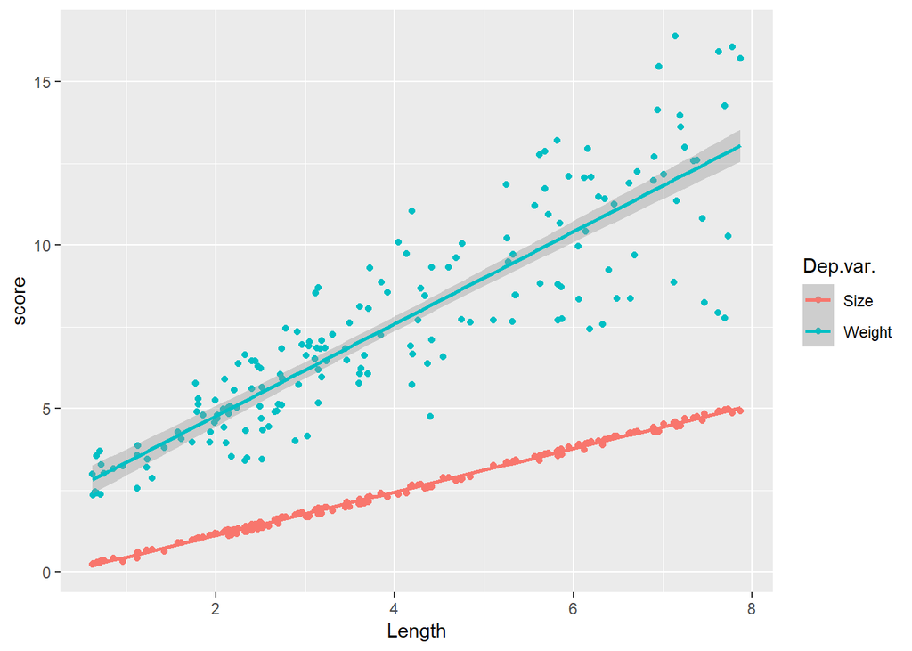

```r
data2 <- data %>% gather(key = "Dep.var.", value = "score", Size, Weight)
library(ggplot2)
ggplot(data2, aes(y=score, x=Length, colour=Dep.var.))+
geom_point()+ geom_smooth(method="lm")
```

### Relationship between each dependent variable and predictor

```r
#Relationship between Size (dependent) and Length (predictor) on the one hand, and Weight and Length on the other
mod <- lm(cbind(Size, Weight) ~ Length, data = data)
summary(mod)

# Residuals
resid(mod)

# Fitted values
fitted(mod)

# Variance-covariance matrix
vcov(mod)

# Coefficients (estimate)
coef(mod)

# Residual's standard error
sigma(mod)

# Prediction on new data
datanew <- data.frame(Length = c(2.1, 1.02))
pred <- predict(mod, newdata=datanew)
pred
```

### Assess wether the predictor is jointly contributing to both relationships (i.e., the coefficients covary)

```r
library(car)
Manova(mod)

#Or
Anova(mod)
```

### Linearity

NOTICE: Graphs may not be representative of the adequate conditions for linearity. Codes are purely demonstrative to highlight the methodology.

The “residual versus fitted values” plot should me homegeneous (horizontal red curve around 0). It would mean that whenever fitted values increases, residuals globally remain uniformally distributed around 0. Therefore, the linear regression would be appropriate for the data.

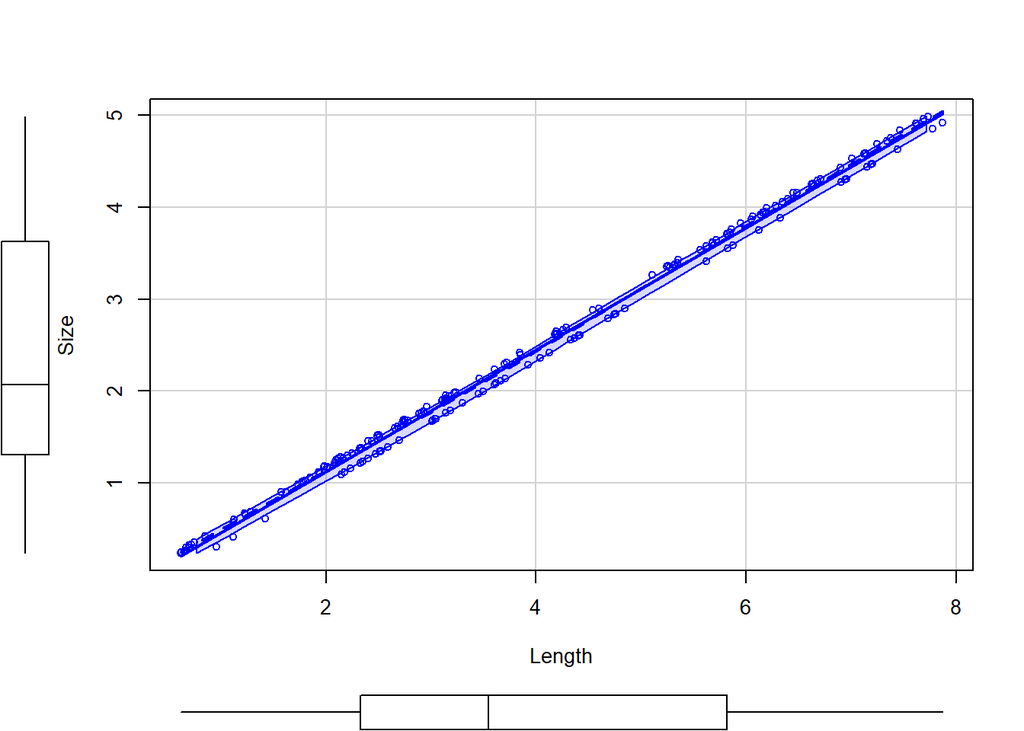

```r
modSize <- lm(Size~Length, data=data)
library(car)
scatterplot(Size~Length, data=data)
```

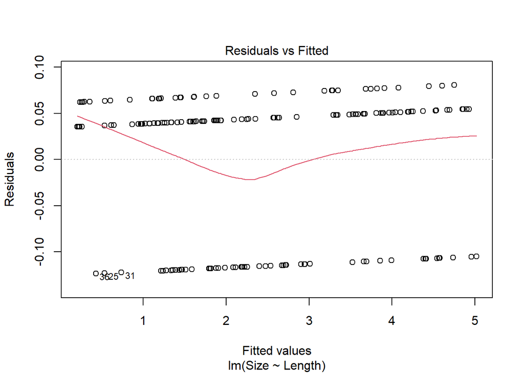

```r
plot(modSize,1)
```

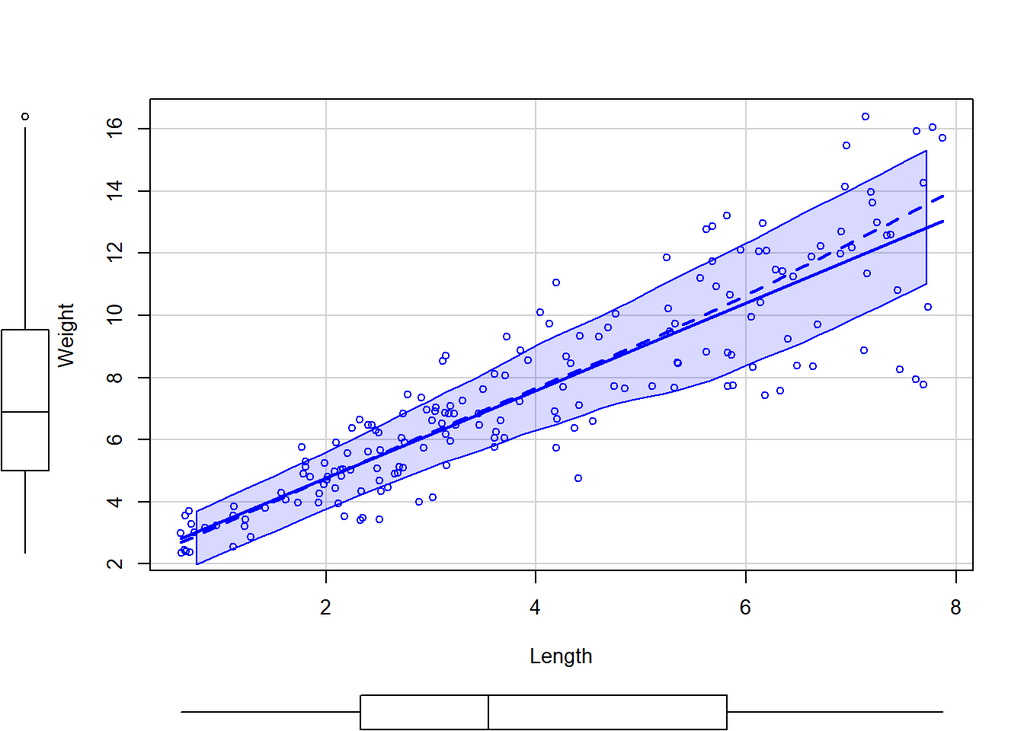

```r
modWeight <- lm(Weight~Length, data=data)
scatterplot(Weight~Length, data=data)
```

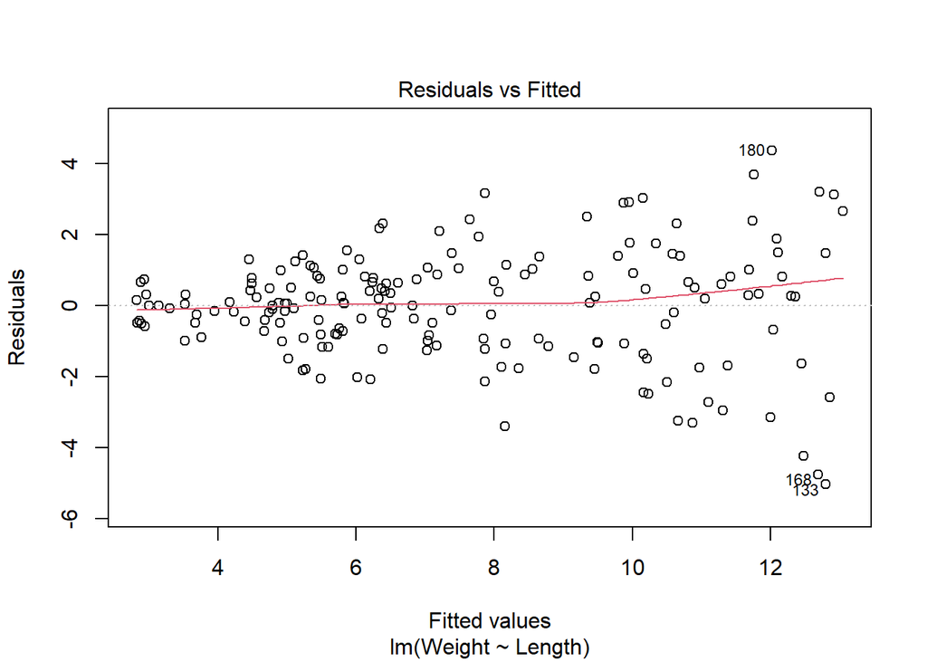

```r
plot(modWeight,1)
```

### Autocorrelation of residuals

NOTICE: Residuals should not be correlated with each other.

Graphs may not be representative of the adequate conditions for absence of autocorrelation of residuals. Codes are purely demonstrative to highlight the methodology.

Horizontal dotted lines are confidence intervals of correlation coefficient = 0. Vertical lines represent correlation coefficients between every residual and its n+x residual (lag=x). Vertical lines should not be higher (or lower) than horizontal lines.

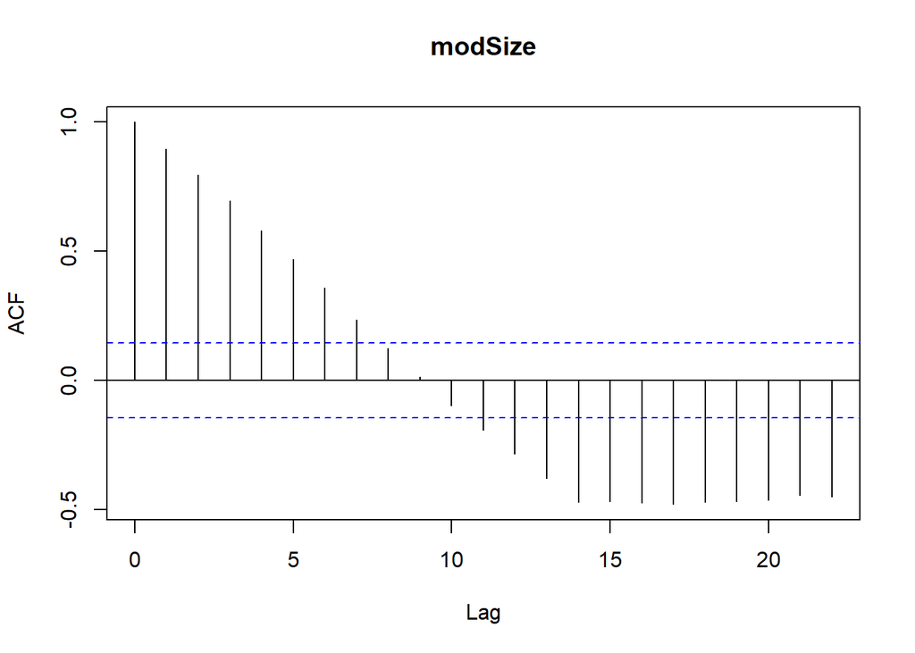

```r
durbinWatsonTest(modSize)
acf(residuals(modSize), main="modSize")
```

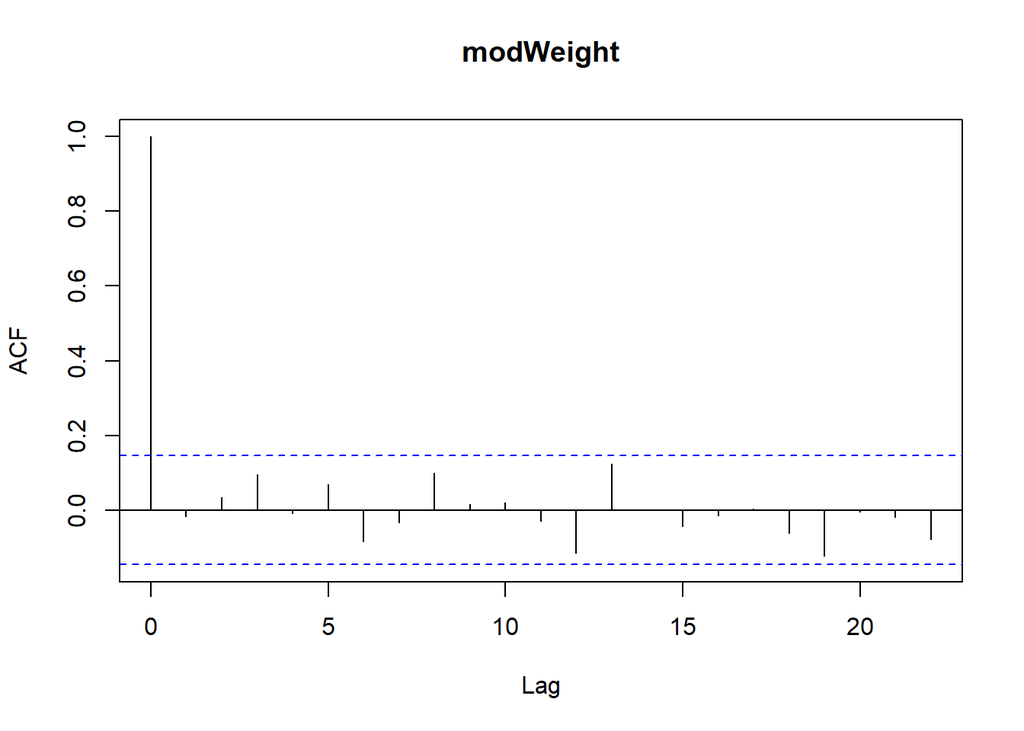

```r
durbinWatsonTest(modWeight)
acf(residuals(modWeight), main="modWeight")
```

### Normality of residuals

NOTICE: Graphs may not be representative of the adequate conditions for homogeneous, and normally distributed residuals. Codes are purely demonstrative to highlight the methodology. Dots of residuals must approximately fall along the reference line to validate normality.

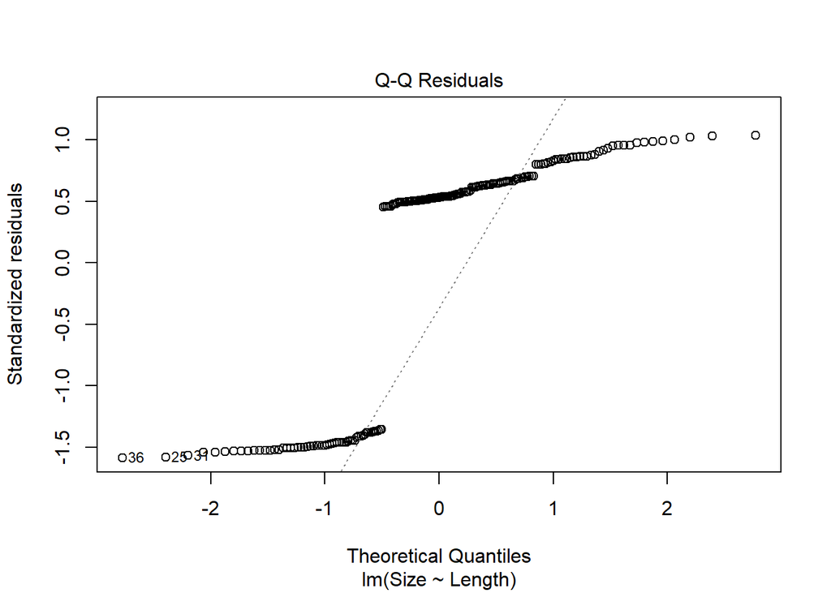

```r
# p>0.05
shapiro.test(residuals(modSize))
plot(modSize,2)
```

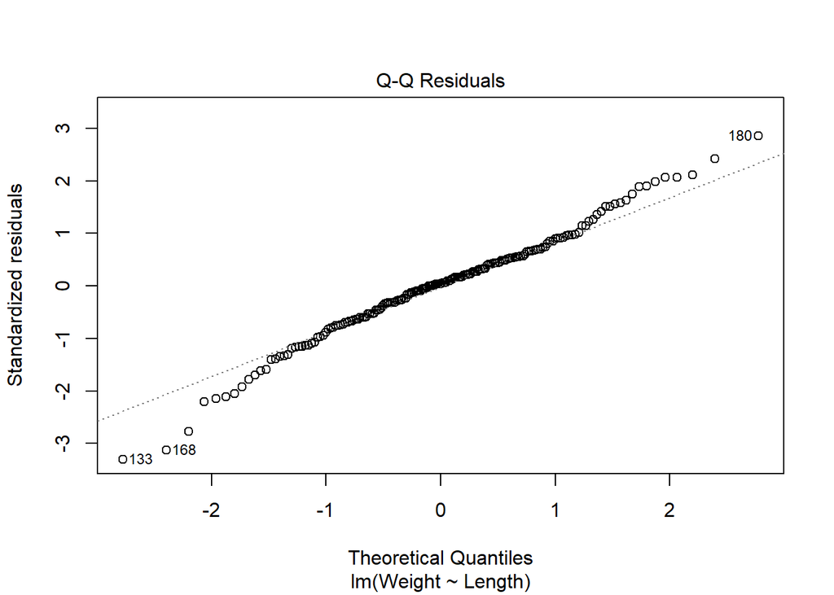

```r
# p>0.05
shapiro.test(residuals(modWeight))
plot(modWeight,2)
```

### Homogeneity of residuals

NOTICE: Graphs may not be representative of the adequate conditions for homogeneously distributed residuals. Codes are purely demonstrative to highlight the methodology.

The red curve is a local regression line, that should approximate horizontality. If horizontal, it shows that residuals tend to be distributed homogeneously around fitted values. Therefore, the homogeneity of residuals should be validated.

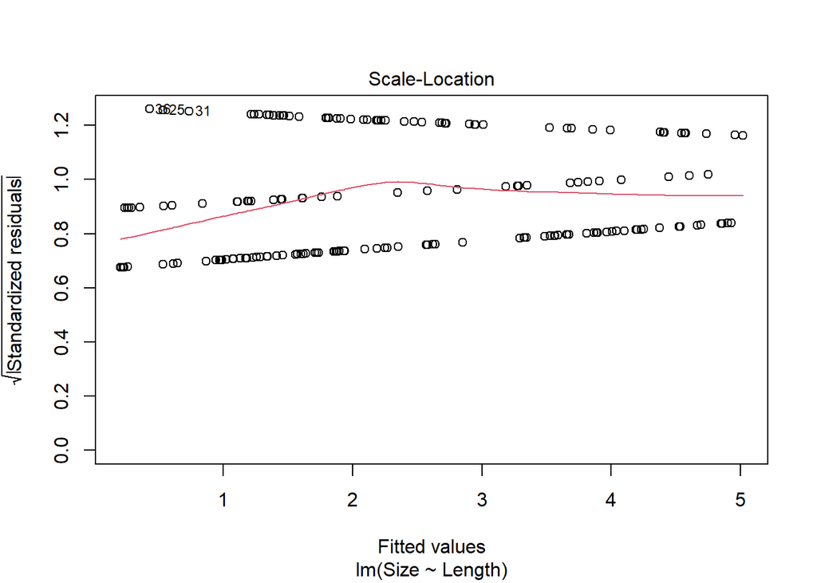

```r
# Breush-Pagan: p>0.05
ncvTest(modSize)
plot(modSize, 3)
```

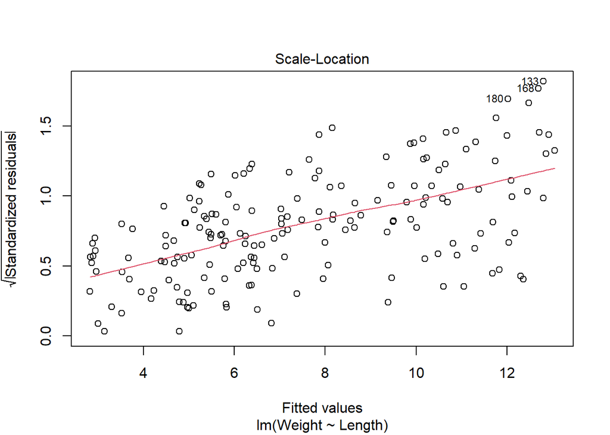

```r
# Breush-Pagan: p>0.05
ncvTest(modWeight)
plot(modWeight, 3)
```

### Outliers

NOTICE: Plots from the “influenceIndexPlot” function represent:

- Cook’s distance (i.e., change in regression coefficients when the value is not considered in the model. More the distance is high, more this value is considered influential).
- Studentized residuals
- Bonferroni’s p-values (p<0.05)
- Hat’s values (<0.05)

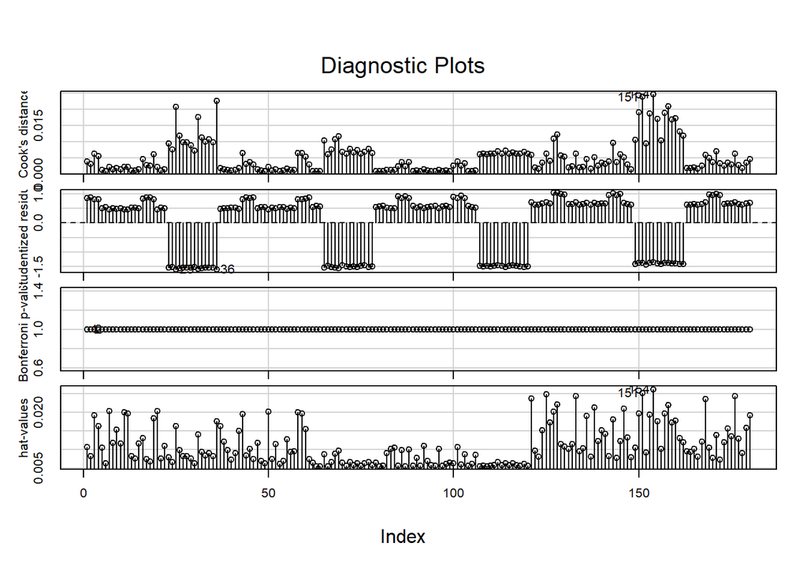

```r
outlierTest(modSize)
influenceIndexPlot(modSize)
```

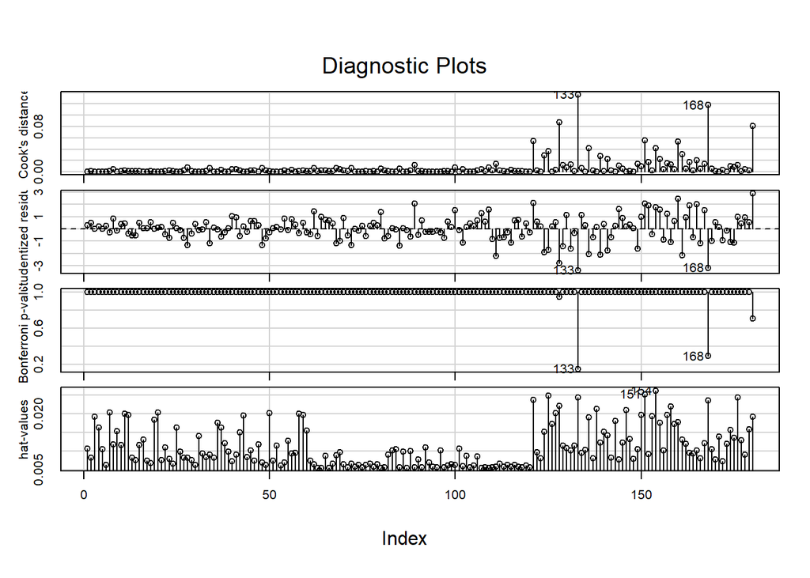

```r
outlierTest(modWeight)
influenceIndexPlot(modWeight)
```

Whenever an influential value is detected, the regression may be run, however, a sensitivity analysis may complement it. That is, the model should be performed again without those values, and coefficients may be compared. For instance, here, values of indexes 151 and 154 (size) have been highlighted as outliers by Cook’s distance and hat’s values. The model is run again without those values and coefficients are compared with the main model:

```r
library(dplyr)
dataSize <- data %>% dplyr::select(-Weight)

modSizebis <- lm(Size~Length, data=dataSize[-c(151,154),])
compareCoefs(modSize,modSizebis)
```

# Ultimate Notice

This code may further be adapted to two-way, three-way and mixed models (with within-id factors). You may refer to the present document complemented with the documentation on ANOVA and ANCOVA provided in the files named “ANOVA” and “MANOVA” to infer the code.